# R Workshop

R Samanta

22nd November 2018

Welcome to the `R` Workshop

## Session objectives

- **Give you a taster of R**
- **Learn how to import and manipulate data**
- **Appreciate the data cycle**
- **Where to go for help**

To download **R Studio** go to http://www.rstudio.com. You also need to download the R program as R studio is a platform that ‘sits on top of’ the `R` program.

To dowload `R` go to http://www.r-project.org

### Exercise 1: Create Variables

```r
a <- c('John', 'Paul', 'George', 'Ringo')
a
```

```
## [1] "John"   "Paul"   "George" "Ringo"
```

```r
b <- c(200, 515, 180, 160)

b / 2
```

```
## [1] 100.0 257.5  90.0  80.0
```

```r
b
```

```
## [1] 200 515 180 160
```

```r
b <- b / 2
b
```

```
## [1] 100.0 257.5  90.0  80.0
```

### Exercise 2: Create a data frame

- Combine the elements `a` and `b` into a data frame called `d` using the `data.frame ( )` function

Notice the difference between the following

```r
e <- c(a, b)
e
```

```
## [1] "John"   "Paul"   "George" "Ringo"  "100"    "257.5"  "90"     "80"
```

```r
e <- data.frame(a, b)
e
```

| a | b |
| --- | --- |
| John | 100.0 |
| Paul | 257.5 |
| George | 90.0 |
| Ringo | 80.0 |

`data.frame` is a function that tells R to make a data table. The inputs of each ‘cell’ can be variables, strings, mathematical models or even lists of lists. It can all become *very* complicated quite quickly.

```r
colnames(e) <- c('Beatle', 'Net_Worth')
e
```

| Beatle | Net_Worth |
| --- | --- |
| John | 100.0 |
| Paul | 257.5 |
| George | 90.0 |
| Ringo | 80.0 |

The Data Frame is the basic unit of storing R that you will be using when importing data from external data sources.

Selecting subsets of data from data frames to allow manipulation is what you will spend most of your time doing in *R*.

You can manipulate data within the data frames.

```r
e$Net_Worth <- e$Net_Worth / 2

e
```

| Beatle | Net_Worth |
| --- | --- |
| John | 50.00 |
| Paul | 128.75 |
| George | 45.00 |
| Ringo | 40.00 |

```r
# or
e[,2] <- e[,2] / 2

e
```

| Beatle | Net_Worth |
| --- | --- |
| John | 25.000 |
| Paul | 64.375 |
| George | 22.500 |
| Ringo | 20.000 |

### Exercise 3: Plot Data

Create a variable `x` which contains the values 0 - 50 in intevals of 5

Create a variable `y` which contains the values 0 - 200 in intevals of 20

```r
x <- seq(0, 50, 5)
y <- seq(0 , 200, 20)
```

Plot x vs y, labelling the x-axis ‘Time’

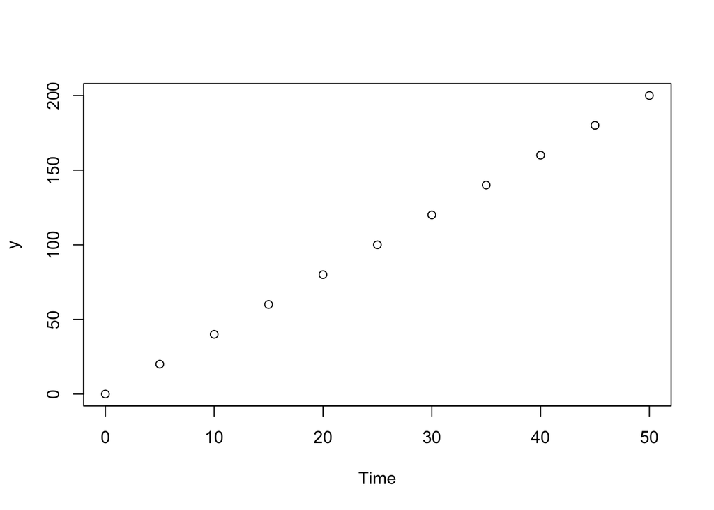

```r
plot(x, y, xlab = 'Time')
```

Create a new variable `y2` which contains the values 0 - 100 in intervals of 10

```r
y2 <- seq(0, 100, 10)
```

Use the `points( )` function to add y2 vs x points to the plot above, colour these points red using the the `col=` argument.

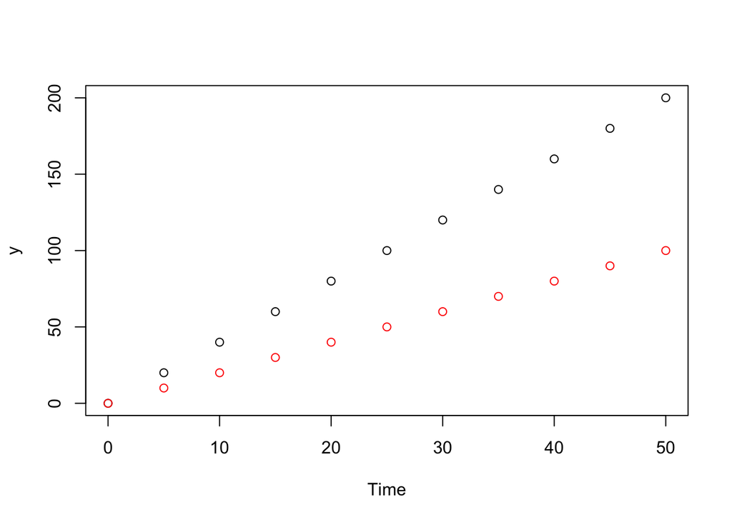

```r
plot(x, y, xlab = 'Time')
points(x, y2, col = 'red')
```

### Importing Data

The *comma seperated values* (CSV) file is the easiest way for *R* to interact with your trial / study data. CSV files are unformatted raw data which can be generated from spreadsheet worksheets (MS Excel, Numbers), databases (MS Access, SQL) or from other programming languages (Linux, Python)

Once data is imported it is essential that you spend some time getting to know it *before* manipulating it or else much angst is liable to ensue.

The data analyst’s maxim should be ‘visualise / clean / model / interpret’

Import the data using the `read.csv()` function into a variable which R will automatically interpret as a data frame.

Before we do this we need to tell R where our data is on our computer.

This uses the `setwd()` [set working directory command] or you can

- Use the files tab to the right to navigate to the location of your files, click on the ‘cog wheel More arrow’ and select ‘Set as Working Directory’
- Use the menu at the top ’Session -> Set Working Directory -> Choose Directory…

There are two .CSV files: Data.csv and Demographics.CSV

```r
vent.data <- read.csv("data.csv", header=TRUE)
demographics <- read.csv("demographics.csv", header = TRUE)
```

If you type in the name of the variable that you have saved each bit of data to `R` will try and call the entire contents of that variable. `vent.data` or `demographics`

A quick way to get some useful metrics about a data frame is to use the `summary ()` function. This will provide information of range, median, IQR and means for numerical variables. It also gives a useful indication of the number of `NA`s which points you in the direction of where cleaning might be needed.

```r
summary(vent.data)
```

```
##       Hosp_no      Ventilator.hour  PlateauPress     PEEP.cmH20
##  F00001216:  150   Min.   :  1.0   Min.   : 5.00   Min.   : 0.000
##  F00001316:  150   1st Qu.: 38.0   1st Qu.:15.00   1st Qu.: 5.000
##  F00001425:  150   Median : 75.5   Median :25.00   Median : 5.000
##  F00001485:  150   Mean   : 75.5   Mean   :24.16   Mean   : 6.984
##  F00001572:  150   3rd Qu.:113.0   3rd Qu.:33.00   3rd Qu.:10.000
##  F00001591:  150   Max.   :150.0   Max.   :45.00   Max.   :22.000
##  (Other)  :29100
##   TidalVol.ml
##  Min.   : 100.0
##  1st Qu.: 412.0
##  Median : 490.0
##  Mean   : 513.9
##  3rd Qu.: 583.0
##  Max.   :5724.0
##
```

```r
summary(demographics)
```

```
##     Hospital_No      Sex          Height        Weight
##  F00001216:  1   Female:144   Min.   :120   Min.   : 40.80
##  F00001316:  1   Male  :156   1st Qu.:145   1st Qu.: 64.58
##  F00001425:  1                Median :161   Median : 86.15
##  F00001485:  1                Mean   :161   Mean   : 88.72
##  F0000154 :  1                3rd Qu.:174   3rd Qu.:112.42
##  F00001572:  1                Max.   :210   Max.   :149.80
##  (Other)  :294
```

Often, like in this example you get data in different ‘bits’ and they don’t always marry up terribly well. Resolving this issue is fairly straightforward in `R`. This can be done in Excel, but it becomes quite computationally slow if you use the ‘vlookup’ and ‘hlookup’ commands many times, especially if you are referring to external files.

Notice something odd about the size of demographics and data?

Let’s see how many unique patients there are in each data set using the `unique()` function:

```r
unique(vent.data[,1])
```

```
##   [1] F00008354 F00020150 F00016403 F00020251 F00008617 F00003579 F00018672
##   [8] F00008977 F00019792 F00015130 F00017131 F00003482 F00011828 F00017906
##  [15] F00013596 F00021397 F00012505 F00021863 F00024428 F00003430 F00014532
##  [22] F00019733 F00022186 F00006340 F00020292 F00006635 F00009735 F00001485
##  [29] F00021001 F00023137 F00002577 F00008729 F00021829 F00008160 F00012268
##  [36] F00018143 F00002628 F00016370 F00022506 F00015739 F00014195 F00014907
##  [43] F00008490 F00007023 F00004127 F00014488 F00003578 F00017386 F00006418
##  [50] F00018642 F00023051 F00016232 F00012242 F00003750 F00002302 F00014365
##  [57] F00010887 F00008063 F00020565 F00011335 F00008735 F00005072 F00007634
##  [64] F00004407 F00001572 F00024589 F00012685 F00020728 F00016989 F00013186
##  [71] F00001600 F00003316 F00022538 F00005278 F00014304 F00004722 F00003339
##  [78] F00001316 F00016699 F00006528 F00020459 F00021350 F00019348 F00009855
##  [85] F00005127 F00011602 F00013450 F00017887 F00019405 F00002370 F00017498
##  [92] F00019139 F00004680 F00008873 F00009704 F00022951 F00006651 F00014505
##  [99] F00009856 F00008127 F00016265 F00006765 F00005892 F00014106 F00017639
## [106] F00010089 F00019935 F00005950 F00007241 F00005269 F00007354 F00007006
## [113] F00016761 F00013550 F00002788 F00017139 F00001425 F00009438 F00022796
## [120] F00020347 F00003116 F00012797 F00020042 F00011536 F00016389 F00022830
## [127] F00007424 F00001591 F00017491 F00017630 F00022585 F00009879 F00014660
## [134] F00003207 F00024307 F00011726 F00011296 F00022659 F00013460 F00024102
## [141] F00012862 F00006839 F00016538 F00001886 F00001216 F00009836 F00001592
## [148] F00002403 F00002039 F00018325 F00007342 F00011559 F00012509 F00006086
## [155] F00006263 F00016089 F00020326 F00014372 F00023903 F00011903 F00008794
## [162] F00015795 F00006762 F00020092 F00022694 F00006610 F00022676 F00019536
## [169] F00003186 F00006576 F00004373 F00014176 F00014008 F00022782 F00007862
## [176] F00011128 F00014537 F00011771 F00023132 F00021057 F00010827 F00023340
## [183] F00013260 F00006930 F00008809 F00014896 F00002127 F00013591 F00013994
## [190] F00011833 F00019257 F00007831 F00019890 F00010798 F00007662 F00012040
## [197] F00018273 F00017284 F00009076 F00014127
## 200 Levels: F00001216 F00001316 F00001425 F00001485 F00001572 ... F00024589
```

```r
unique(demographics[,1])
```

```
##   [1] F00026889 F00026645 F0000358  F00003316 F00027604 F00016089 F00008729
##   [8] F00013460 F00008977 F00003430 F00006930 F00016699 F00026295 F0000803
##  [15] F00022782 F00021350 F00020326 F00002370 F00001216 F00026060 F0000760
##  [22] F00012685 F00027751 F00026086 F00014532 F00017491 F00017887 F00007634
##  [29] F00003207 F00017639 F0000154  F00007831 F00014106 F00026053 F00021057
##  [36] F00026059 F00017906 F00019405 F00022796 F00011296 F00027503 F00011128
##  [43] F00022951 F0000342  F00016761 F00006340 F00011335 F0000867  F0000225
##  [50] F00022830 F00026074 F00005278 F00022186 F00017139 F00021863 F00018672
##  [57] F00024102 F00018143 F00011726 F00014505 F00006576 F00012268 F00005072
##  [64] F00019890 F00004373 F00008490 F00019935 F00014008 F00026368 F00005892
##  [71] F00019536 F00013591 F0000469  F00022506 F00008160 F00024589 F00008809
##  [78] F00014127 F00026198 F00010887 F00009076 F0000318  F00021829 F0000416
##  [85] F00013450 F00014195 F0000181  F00007241 F00016989 F00020459 F000030
##  [92] F00026119 F00004127 F00013186 F00006635 F00007662 F00024428 F00003579
##  [99] F00021397 F00027164 F00027794 F00014896 F00001600 F00002577 F0000533
```

[output cut: 29 more lines]

Not obvious? We can combine functions to make things easier for us:

```r
length(unique(vent.data[,1]))
```

```
## [1] 200
```

```r
length(unique(demographics[,1]))
```

```
## [1] 300
```

So we have more patient id’s than ventilator data and we have to selectively merge them.

Merging two databases is called joining (that is all you want / need to know aboout databases for now).

There are lots and lots of ways to do this.

Let’s see which are the common hospital numbers using the `which()` function and a really useful logical operater called `%in%` - which basically means ‘find the common elements of.’

`which(demographics$Hospital_No %in% vent.data$Hosp_no)` Store these as good_pats

`good_pats <- which(demographics$Hospital_No %in% vent.data$Hosp_no)`

`good_pats` is only a list of numbers

`good_pats`

We need to tell R to select these rows from the demographics and bin the rest

`good_demogs <- demographics[good_pats, ]`

`head(good_deogs)`

`dim(good_demogs)`

In computing there is always a better way of doing this, `R` will merge two databases using headers title names but in our case the headers are not the same.

We can use the `colnames()` function to change the header name of our column we want to and then use the `merge ()` function.

```r
colnames(vent.data)[1] <- 'Hospital_No'

head(vent.data)
```

|  | Hospital_No | Ventilator.hour | PlateauPress | PEEP.cmH20 | TidalVol.ml |
| --- | --- | --- | --- | --- | --- |
| 1 | F00008354 | 1 | 9 | 7 | 511 |
| 2 | F00008354 | 2 | 15 | 7 | 505 |
| 3 | F00008354 | 3 | 11 | 10 | 472 |
| 4 | F00008354 | 4 | 15 | 10 | 491 |
| 5 | F00008354 | 5 | 11 | 10 | 493 |
| 6 | F00008354 | 6 | 17 | 7 | 496 |

```r
# remember to store your merged data in a new variable / data frame
all.vent.data <- merge(vent.data,
                       demographics,
                       by ='Hospital_No')
head(all.vent.data)
```

|  | Hospital_No | Ventilator.hour | PlateauPress | PEEP.cmH20 | TidalVol.ml | Sex | Height | Weight |
| --- | --- | --- | --- | --- | --- | --- | --- | --- |
| 1 | F00001216 | 1 | 39 | 10 | 741 | Female | 151 | 87 |
| 2 | F00001216 | 2 | 13 | 10 | 536 | Female | 151 | 87 |
| 3 | F00001216 | 3 | 30 | 8 | 533 | Female | 151 | 87 |
| 4 | F00001216 | 4 | 31 | 8 | 560 | Female | 151 | 87 |
| 5 | F00001216 | 5 | 29 | 8 | 566 | Female | 151 | 87 |
| 6 | F00001216 | 6 | 27 | 8 | 570 | Female | 151 | 87 |

Notice something odd?

The table has been reordered numerically by Hospital Number by R automatically. This is ok in our case but it might have cause some distress.

The way round this to create an index in the original data frame and keep that index throughout as a form of tracking variable.

Note that this is not always necessary

```r
# going back to the original data frame 'vent.data '

vent.data$index <- as.integer(factor(vent.data$Hospital_No, levels= unique(vent.data$Hospital_No)))
head(vent.data)
```

|  | Hospital_No | Ventilator.hour | PlateauPress | PEEP.cmH20 | TidalVol.ml | index |
| --- | --- | --- | --- | --- | --- | --- |
| 1 | F00008354 | 1 | 9 | 7 | 511 | 1 |
| 2 | F00008354 | 2 | 15 | 7 | 505 | 1 |
| 3 | F00008354 | 3 | 11 | 10 | 472 | 1 |
| 4 | F00008354 | 4 | 15 | 10 | 491 | 1 |
| 5 | F00008354 | 5 | 11 | 10 | 493 | 1 |
| 6 | F00008354 | 6 | 17 | 7 | 496 | 1 |

```r
tail(vent.data)
```

|  | Hospital_No | Ventilator.hour | PlateauPress | PEEP.cmH20 | TidalVol.ml | index |
| --- | --- | --- | --- | --- | --- | --- |
| 29995 | F00014127 | 145 | 15 | 5 | 500 | 200 |
| 29996 | F00014127 | 146 | 10 | 5 | 488 | 200 |
| 29997 | F00014127 | 147 | 15 | 5 | 187 | 200 |
| 29998 | F00014127 | 148 | 16 | 5 | 482 | 200 |
| 29999 | F00014127 | 149 | 9 | 0 | 447 | 200 |
| 30000 | F00014127 | 150 | 9 | 0 | 659 | 200 |

```r
# looks good, so remerge like we did before
all.vent.data <- merge(vent.data, demographics, by ='Hospital_No')
head(all.vent.data)
```

|  | Hospital_No | Ventilator.hour | PlateauPress | PEEP.cmH20 | TidalVol.ml | index | Sex | Height | Weight |
| --- | --- | --- | --- | --- | --- | --- | --- | --- | --- |
| 1 | F00001216 | 1 | 39 | 10 | 741 | 145 | Female | 151 | 87 |
| 2 | F00001216 | 2 | 13 | 10 | 536 | 145 | Female | 151 | 87 |
| 3 | F00001216 | 3 | 30 | 8 | 533 | 145 | Female | 151 | 87 |
| 4 | F00001216 | 4 | 31 | 8 | 560 | 145 | Female | 151 | 87 |
| 5 | F00001216 | 5 | 29 | 8 | 566 | 145 | Female | 151 | 87 |
| 6 | F00001216 | 6 | 27 | 8 | 570 | 145 | Female | 151 | 87 |

```r
# and now reorder using the order () function
all.vent.data <- all.vent.data[order(all.vent.data$index),]
head(all.vent.data)
```

|  | Hospital_No | Ventilator.hour | PlateauPress | PEEP.cmH20 | TidalVol.ml | index | Sex | Height | Weight |
| --- | --- | --- | --- | --- | --- | --- | --- | --- | --- |
| 9601 | F00008354 | 1 | 9 | 7 | 511 | 1 | Female | 165 | 74.3 |
| 9602 | F00008354 | 2 | 15 | 7 | 505 | 1 | Female | 165 | 74.3 |
| 9603 | F00008354 | 3 | 11 | 10 | 472 | 1 | Female | 165 | 74.3 |
| 9604 | F00008354 | 4 | 15 | 10 | 491 | 1 | Female | 165 | 74.3 |
| 9605 | F00008354 | 5 | 11 | 10 | 493 | 1 | Female | 165 | 74.3 |
| 9606 | F00008354 | 6 | 17 | 7 | 496 | 1 | Female | 165 | 74.3 |

Creating indexes is helpful with patient data as it avoids having to type out hospital numbers / unique identifiers repeatedly.

Caution is advised however, as if you remove patients with ongoing cleaning then you may have a gap in your index. The patients can be reodered/indexed again and they’ll all be pretty much the same number, only if you have seperate data frames the indexes will no longer match. Very messy work.

### Categorical data

Not all text is of equal standing. R does not know how to differentiate text that represents categories from just standard text terms.

We can covert data (text or numerical) to categeroies using the `factor()` function. This function can also take the argument `levels =` where you provide a list of categories that you wish to assign, in the the order that you want.

If you stipulate a level term that the text or numerical data does not correspond to, then that data point will be attributed a missing value `NA`.

Changing the sex column to a factor (categorical data type) is done by assinging the ‘factored’ variable back onto its own (or a new) column:

```r
all.vent.data$Sex <- factor(all.vent.data$Sex,
                            levels = c("Female", "Male"))
```

### Visualising Data

‘Factors’ is the `R` way of interpreting text strings as categorical data. This is really useful for splitting or analysing data by sex / age group etc.

Using the factors allows R to quickly seperate data so it can be visualised easily A basic boxplot for example:

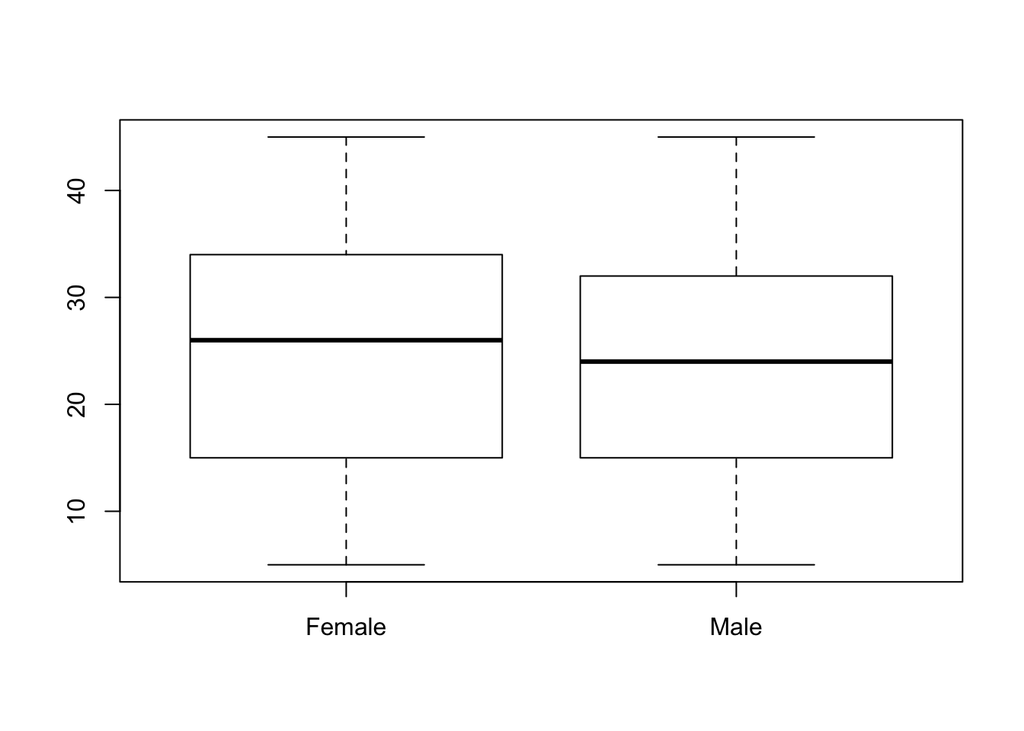

```r
boxplot(all.vent.data$PlateauPress ~ all.vent.data$Sex)
```

We can make our plots a little prettier using some arguements

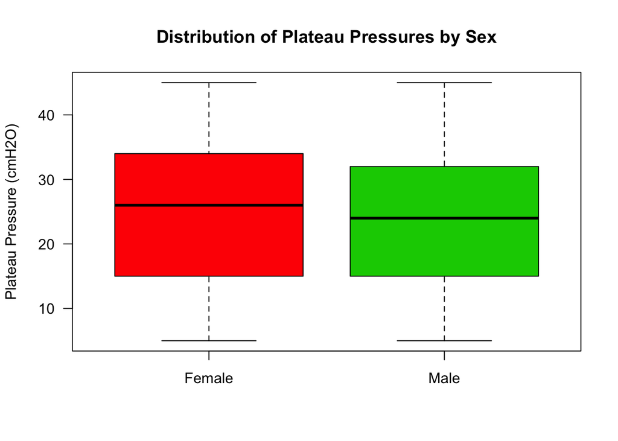

```r
boxplot(all.vent.data$PlateauPress ~ all.vent.data$Sex, col = c(2,3), main = 'Distribution of Plateau Pressures by Sex', ylab = 'Plateau Pressure (cmH2O)', las = 1)
```

If we want to look at individual patient data we can use a function called `subset` which uses logical arguments to slice through data frames.

```
  subset ( < column wanted >, < logical condition to be met > )
```

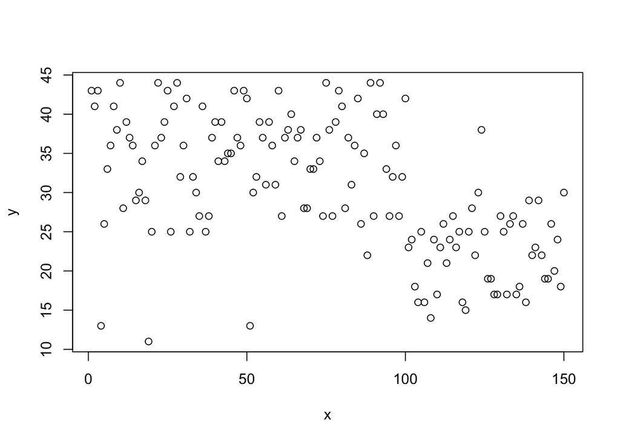

```r
x <- subset(all.vent.data$Ventilator.hour, all.vent.data$index==85)
y <- subset(all.vent.data$PlateauPress, all.vent.data$index==85)

plot(y ~ x) # or you can use plot(x, y)  the ~ identifies dependant and independant variables
```

.